# Life Expectancy

### Kindly note that run code first to generate the graphs and charts.

> ——– IMPORTANT ——— IMPORTANT ——— IMPORTANT If you are running this file first time, kindly uncomment below installation commands. For uncommenting the commands remove the # from beginning of the below commands.

```bash
# install.packages("pastecs")
# install.packages("stringr")
# install.packages("dplyr")
# install.packages("ggplot2")
# install.packages("GGally")
```

> All libraries that we required

```bash
library(pastecs)
library(stringr)
library(dplyr)
library(ggplot2)
library(GGally)
```

> To hide all the unnecessary warnings

```bash
options(warn=-1)
```

> Set current working directory.

```bash
setwd(getwd())
```

> We have read and store the data from CSV to data variable

```bash
data <- read.csv("life_expectancy.csv", na.strings = "")
print(data)
```

> The first thing that we should do is check the class of your data frame

```bash
class(data)
```

> Next, we want to check the number of rows and columns the data frame has.

```bash
dim(data)
```

> We can view the summary statistics for all the columns of the data frame

```bash
summary(data)
```

> Using above summary we can able to find out is database having correct column type or not like above life_expectancy has type character that is why we have to convert that into numerical. Converting all character type columns as a numerical type.

```bash
cols.num <- c("life_expectancy","adult_mortality","alcohol","percentage_expenditure","hepatitis_b","bmi","polio","total_expenditure","diphtheria","gdp","population","schooling")
data[cols.num] <- sapply(data[cols.num],as.numeric)
```

> —————*** Started data cleaning process ***—————

> Trimming the whitespaces

```bash
data$life_expectancy<-str_trim(data$life_expectancy)
data$percentage_expenditure<-str_trim(data$percentage_expenditure)
data$hepatitis_b<-str_trim(data$hepatitis_b)
```

> Here our plan is to fill out all missing values with mean of respective column, that is why why we have to follow below 4 steps,

> |—–> STEP 1 Checking if dataset has any NA value

```bash
any(is.na(data$he))
```

> |—–> STEP 2 Replacing all na values with 0

```bash
data[is.na(data)] <- 0
```

> |—–> STEP 3 Once again converting values into numeric

```bash
data[cols.num] <- sapply(data[cols.num],as.numeric)
```

> |—–> STEP 4 Filling out all missing values with mean of respective column Note that we are performing this oly for columns those has numerical data, it will help us to get proper stats.

```bash
for(b in cols.num){ data$b <- replace(data$b, data$b == 0, mean(data$b)) }
```

> Now check if our dataset having any missing value or na value or not

```bash
any(is.na(data))
```

> —————*** Statistics on given data ***—————

> Removing year column, we dont need it for now

```bash
data_without_error = subset(data, select = -c(year))
```

> Average life expectancy of all over the worlds

```bash
mean(data_without_error$life_expectancy)
```

> Check the avg life expectancy by countries We can able to see that the life expectancy in developed countries is 20% greater than developing countries.

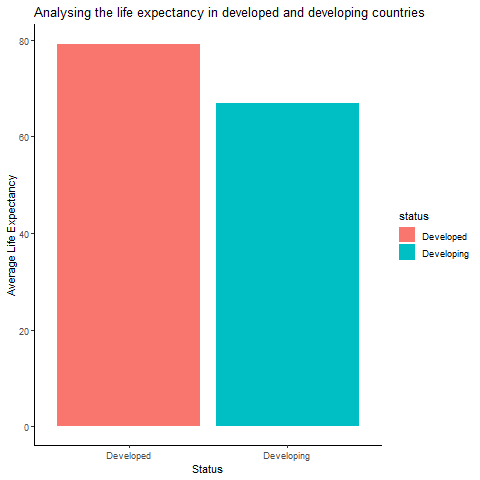

```bash
png(file="Rplot2.png")
data_without_error %>%
  group_by(status) %>%
  summarise(average_life_expectancy = mean(life_expectancy)) %>%
  ggplot(aes(x = status, y = average_life_expectancy, fill = status)) +
  geom_bar(stat = "identity") +
  theme_classic() +
  labs(
    x = "Status",
    y = "Average Life Expectancy",
    title = paste(
      "Analysing the life expectancy in developed and developing countries"
    )
  )
dev.off()
```

> We can see that the life expectancy is higher in developed nations like UK, Canada and there is 20% drop in life expectance in developing nations like Afghanistan, Yemen, Etc.

> —————*** Why life expectancy is greater in developed nations ***—————

> Now on previous step we able to know that life expectancy in developed countries is 20% greater than developing countries. We have to check now WHY?

> Creating dataset for correlation We have to remove character datatype columns like country and status

```bash
cor_dataset <- data
cor_dataset = subset(cor_dataset, select = -c(country, status, year))
```

> Convert required columns into numerical format.

```bash
cor_dataset[cols.num] <- sapply(cor_dataset[cols.num],as.numeric)
```

> Printing correlation

```bash
round(cor(cor_dataset),
      digits = 2 > rounded to 2 decimals
)
whole_data <- data
```

> —————*** Feature Selection ***—————

> Convert required columns into numerical format.

```bash
whole_data[cols.num] <- sapply(whole_data[cols.num],as.numeric)
```

> All countries need to reach ≥90% national coverage for all vaccines in the country’s routine immunization schedule by 2020. Based on that statement, we are going to mutate the Hepatitis.B, Polio, and Diphtheria into a categorical variable, with 2 value: “Under 90% Covered” and “Covered by 90% or More”. By doing this, hopefully we can get a better view on the immunization impact to Life.expectancy. |—–> Data Wrangling

```bash
life_selected <- whole_data %>%
  select(-whole_data$Country, -whole_data$Year) %>%
  mutate(Hepatitis.B = ifelse(whole_data$hepatitis_b < 90, "<90% Covered", ">=90% Covered"),
         Polio = ifelse(whole_data$polio < 90, "<90% Covered", ">=90% Covered"),
         Diphtheria = ifelse(whole_data$diphtheria < 90, "<90% Covered", ">=90% Covered"),
         Hepatitis.B = as.factor(whole_data$hepatitis_b),
         Polio = as.factor(whole_data$polio),
         Diphtheria = as.factor(whole_data$diphtheria))

str(life_selected)
```

> Mutate hepatitis_b: Range between min value & the Quartile is very wide have to be manipulated. Mutate diphtheria -> Range between min value & the Quartile is very wide have to be manipulated. Mutate polio: Range between min value & the Quartile is very wide have to be manipulated.

> —————*** Correlations and Variances ***—————

```bash
data_num <- life_selected %>%
  select_if(is.numeric)
```

> Looks like life_expectancy dependent variable strong positive with alcohol (0.36), polio (0.43), diphtheria (0.44), schooling (0.56)

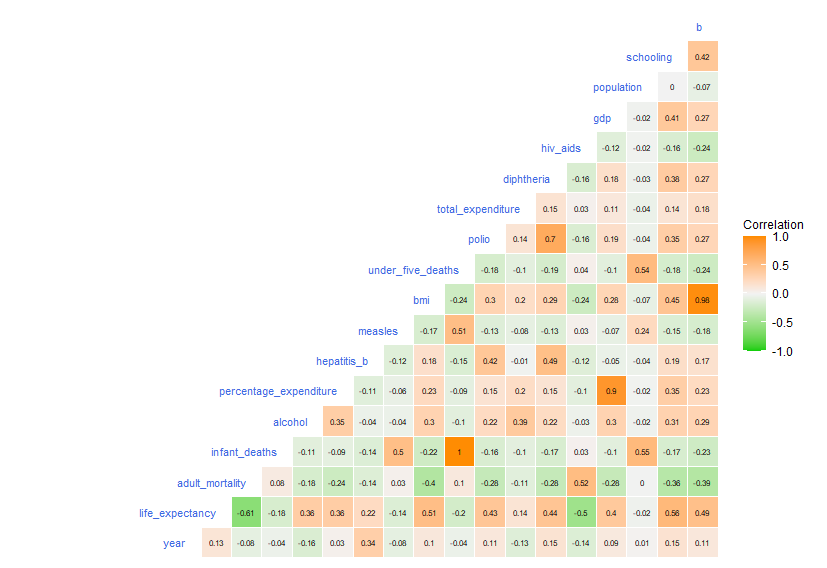

```bash
png(file="Rplot3.png")
ggcorr(data_num,
       label = T,
       label_size = 2,
       label_round = 2,
       hjust = 1,
       size = 3,
       color = "royalblue",
       layout.exp = 5,
       low = "green3",
       mid = "gray95",
       high = "darkorange",
       name = "Correlation")
dev.off()
```

> Taking one developed country data We are going to take United Kingdom of Great Britain and Northern Ireland data

```bash
UK_data <- life_selected
```

> Filtering and taking only UK’s data

```bash
UK_data <- subset( UK_data, country == "United Kingdom of Great Britain and Northern Ireland")
```

> Convert required columns into numerical format.

```bash
UK_data[cols.num] <- sapply(UK_data[cols.num],as.numeric)
```

> Here we can able to analysed that life expectancy is increasing till 2013 and suddenly it gets decreased. WHY suddenly it gets decreased after 2013 Why its increasing till 2013

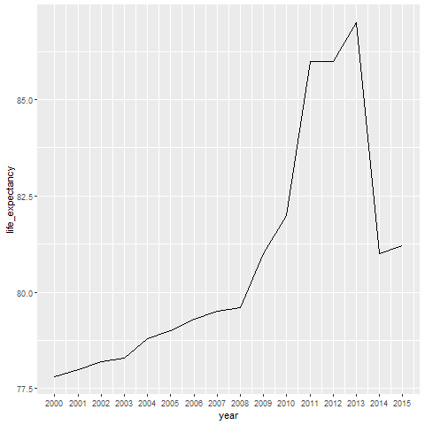

```bash
png(file="Rplot4.png")
ggplot(UK_data, aes(year, life_expectancy)) + geom_line() + scale_x_continuous(labels=UK_data$year,breaks=UK_data$year)
dev.off()
```

> Correlation graph

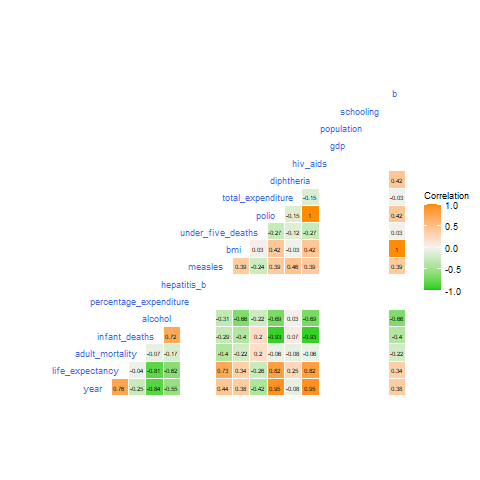

```bash
png(file="Rplot5.png")
ggcorr(UK_data,
       label = T,
       label_size = 2,
       label_round = 2,
       hjust = 1,
       size = 3,
       color = "royalblue",
       layout.exp = 5,
       low = "green3",
       mid = "gray95",
       high = "darkorange",
       name = "Correlation")
dev.off()
```

> Now Taking one developing country data We are going to take Afghanistan data

```bash
Afghanistan_data <- life_selected
```

```bash
Afghanistan_data <- subset( Afghanistan_data, country == "Afghanistan")
```

> Convert required columns into numerical format.

```bash
Afghanistan_data[cols.num] <- sapply(Afghanistan_data[cols.num],as.numeric)
```

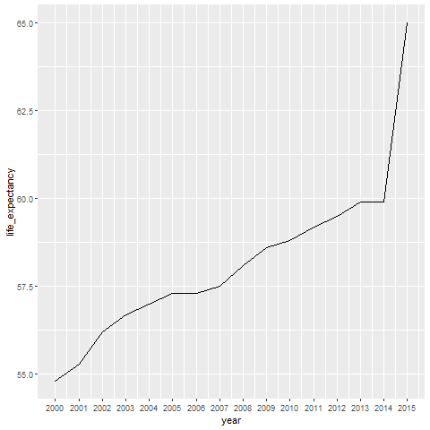

```bash
png(file="Rplot6.png")
ggplot(Afghanistan_data, aes(year, life_expectancy)) + geom_line() + scale_x_continuous(labels=Afghanistan_data$year,breaks=Afghanistan_data$year)
dev.off()
```

> Correlation graph

```bash
png(file="Rplot7.png")
ggcorr(Afghanistan_data,
       label = T,
       label_size = 2,
       label_round = 2,
       hjust = 1,
       size = 3,
       color = "royalblue",
       layout.exp = 5,
       low = "green3",
       mid = "gray95",
       high = "darkorange",
       name = "Correlation")
dev.off()
```

[figure not shown]

> Looks like the dependent variable life expectancy is strongly correlated with percentage_expenditure (0.89), gdp (0.68), diphtheria (0.81), schooling(0.84) We can able to see dependent variable life expectancy is negatively correlated with adult_mortality, which is valid because if mortality rate of adults is high, then the life expectancy of people will be low.

> —————*** Model Creation ***—————

> We are going to predict the Life.expectancy by using Selected Variables. And this is the full linear prediction model.

```bash
life_model <- lm(life_selected$life_expectancy ~  life_selected$life_expectancy + life_selected$adult_mortality + life_selected$alcohol + life_selected$percentage_expenditure + life_selected$hepatitis_b + life_selected$bmi + life_selected$polio + life_selected$total_expenditure + life_selected$diphtheria + life_selected$gdp + life_selected$population + life_selected$schooling, data = life_selected)
summary(life_model)
```

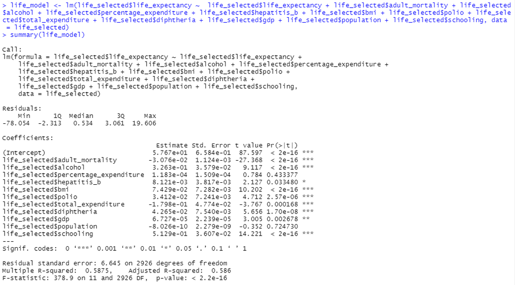

> Adj. R-squared interpretation: Approximately 58.6% of the observed variation can be explained by the model’s inputs, this is a not better but we can say good result But still indicating that we are on the right path to create good linear model.

```bash
life_full <- lm(formula = life_expectancy ~., data = life_selected)
life_none <- lm(formula = life_expectancy ~1, data = life_selected)
```

```bash
model_backward <- step(life_full, direction = "backward")
summary(model_backward)
```

```bash
model_forward <- step(life_none, scope = list(lower = life_none, upper = life_full) ,direction = "forward")
summary(model_forward)
```

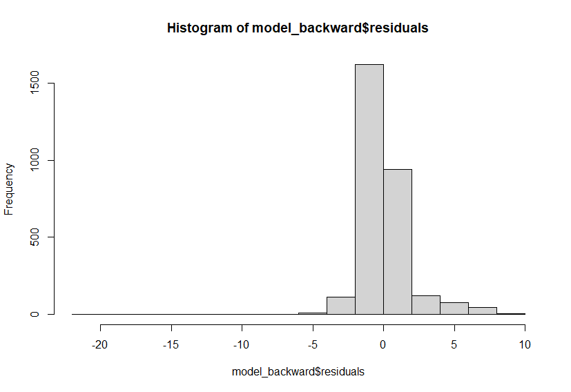

```bash
png(file="Rplot9.png")
hist(model_backward$residuals, breaks = 20)
dev.off()
```

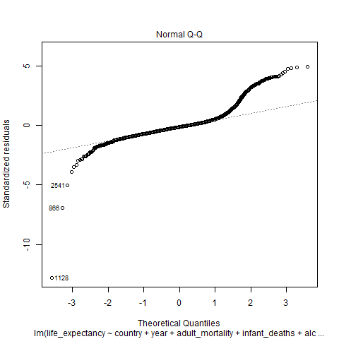

```bash
png(file="Rplot10.png")
plot(model_backward, which = 2)
dev.off()
```

```bash
shapiro.test(model_backward$residuals)
```

> Remove Outliers We will try to remove the Outliers that keeped on previous findings. visual boxplot

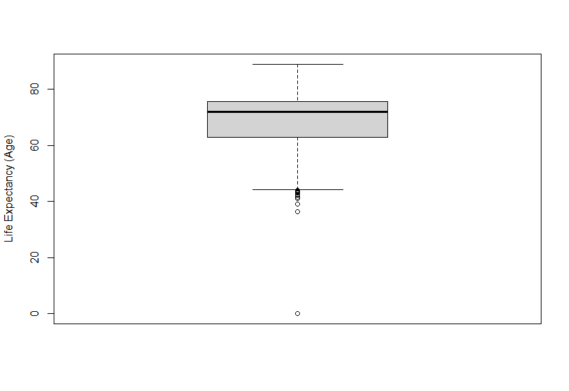

```bash
png(file="Rplot11.png")
boxplot(life_selected$life_expectancy, ylab = "Life Expectancy (Age)")
dev.off()
```

> untuk mendaptkan outlier

```bash
outliers_out <- boxplot(life_selected$life_expectancy, plot = F)$out
```

> remove outlier dari data

```bash
life_clean <- life_selected[-which(life_selected$life_expectancy %in% outliers_out), ]
```

> Let us see the Boxplot after Outliers taken

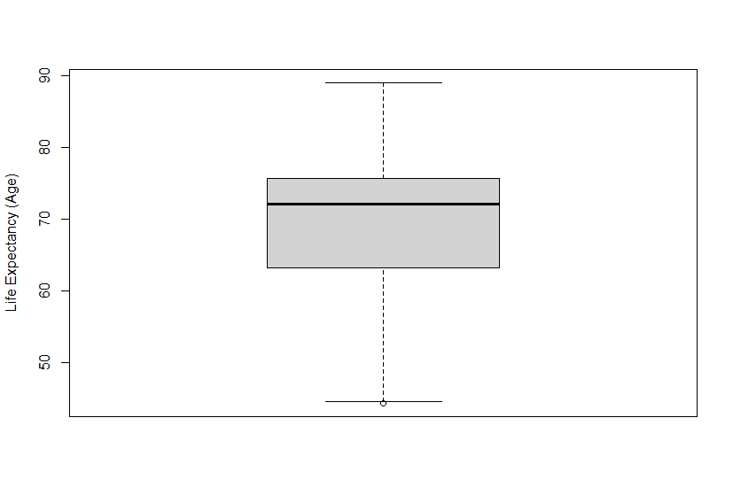

```bash
png(file="Rplot12.png")
boxplot(life_clean$life_expectancy, ylab = "Life Expectancy (Age)") # visual boxplot
dev.off()
```